Stakeholder - Teaching Staff: Unit of Study Coordinator

# Executive Summary

This report aims to analyse and give some insight on whether increased usage of the University of Sydney Canvas website results in a better unit of study mark for junior Maths units. The stakeholder this report is aimed at is the Course Coordinators for these units of study. From the data it was noted that the student with the highest mark out of the entire cohort used the canvas website at least once every week during each of the thirteen teaching weeks.

# Initial Data Analysis (IDA)

```r
#packages
library(tidyverse)
```

```r
library(ggplot2)
library(reshape2)
#loading data
UniData = read.csv("DATA1001_2019_S2C_PROJECT3_DATA_v2.csv", header = TRUE)

#combining columns
#Weeks 1 - 13
colnms = c ("Canvas.access.Week.1", "Canvas.access.Week.2", "Canvas.access.Week.3", "Canvas.access.Week.4", "Canvas.access.Week.5", "Canvas.access.Week.6", "Canvas.access.Week.7", "Canvas.access.Week.8", "Canvas.access.Week.9", "Canvas.access.Week.10", "Canvas.access.Week.11", "Canvas.access.Week.12", "Canvas.access.Week.13")

#Adding a new column Sum of Attendance from Week 1 - 13
Newdata <- UniData %>%
  group_by(id = row_number()) %>%
  nest(colnms) %>%
  mutate(SUM = map_dbl(data,sum))
UniData$TotalCanvasAccess <- Newdata$SUM

str(UniData)
```

```
## 'data.frame':    10845 obs. of  27 variables:
##  $ Fake.Student.Identifier         : int  2171 2343 1385 1985 4038 3188 3888 2650 2 3454 ...
##  $ Gender                          : Factor w/ 2 levels "F","M": 2 2 1 1 2 2 1 1 1 2 ...
##  $ Age.at.Semester.Start           : Factor w/ 4 levels "18 and under",..: 2 2 2 2 2 1 2 2 4 3 ...
##  $ Domestic...international.status : Factor w/ 2 levels "Domestic","International": 1 2 1 1 2 1 2 2 1 2 ...
##  $ Mode.of.Study                   : Factor w/ 3 levels "Full Time","Part Time",..: 1 1 1 1 1 1 1 1 1 1 ...
##  $ Semester                        : int  1 2 1 1 1 2 1 2 1 1 ...
##  $ Fake.UoS.Identifier             : Factor w/ 15 levels "UNIT A","UNIT B",..: 9 5 9 3 9 6 9 4 9 12 ...
##  $ UoS.Mark                        : int  73 71 64 69 78 88 46 51 65 83 ...
##  $ UoS.changes.before.Week.1       : int  0 6 20 14 0 6 2 0 0 0 ...
##  $ UoS.changes.before.Week.2       : int  0 8 20 14 0 6 6 0 0 0 ...
##  $ UoS.changes.before.census.date  : int  4 8 20 14 0 6 6 0 0 0 ...
##  $ Canvas.access.Week.1            : int  1 1 1 1 1 1 1 1 1 1 ...
##  $ Canvas.access.Week.2            : int  1 1 1 1 1 1 1 1 1 1 ...
##  $ Canvas.access.Week.3            : int  1 1 1 1 1 1 1 1 1 1 ...
##  $ Canvas.access.Week.4            : int  1 1 1 1 1 1 1 1 1 1 ...
##  $ Canvas.access.Week.5            : int  1 1 1 1 1 1 1 1 1 1 ...
##  $ Canvas.access.Week.6            : int  1 1 1 1 1 1 1 1 1 1 ...
##  $ Canvas.access.Week.7            : int  1 1 1 1 1 1 1 1 1 1 ...
##  $ Canvas.access.Week.8            : int  1 1 1 1 1 1 1 1 1 1 ...
##  $ Canvas.access.Week.9            : int  1 0 1 1 1 0 1 1 1 1 ...
##  $ Canvas.access.Week.10           : int  1 1 1 1 1 1 1 1 1 1 ...
##  $ Canvas.access.Week.11           : int  1 1 1 1 1 1 1 1 1 1 ...
##  $ Canvas.access.Week.12           : int  1 1 1 1 1 1 1 1 1 1 ...
##  $ Canvas.access.Week.13           : int  1 0 1 1 1 1 1 1 1 1 ...
##  $ Canvas.access.Mid.semester.break: int  0 1 1 1 1 1 1 1 1 1 ...
##  $ Canvas.access.STUVAC            : int  0 1 1 1 1 1 1 1 1 1 ...
##  $ TotalCanvasAccess               : num  13 11 13 13 13 12 13 13 13 13 ...
```

# Research Question 1

## Did use of Canvas and its resources assist students in their studies?

The two variables were analysed in this research question, the cumulative number of weeks that students accessed the canvas website and their UoS marks. It is assumed that students whom accessed the canvas website utilised the given materials.

From the graph below, it is observed that the student with the highest mark accessed the canvas website every week out of the thirteen weeks. There was a weak correlation between the two variables with a correlation coefficient of 0.18, thus the canvas access may not necessarily imapct student marks. This idea is suggested by a study performed in 2015 which assessed the resources that a cohort students used in preparation for their final exams. It was found that students whom utilised additional study material such as textbooks outside of material given by the school performed better overall (J. Sanjoy, 2005).

```r
#regression
lm(TotalCanvasAccess ~ UoS.Mark, data = UniData)
```

```
##
## Call:
## lm(formula = TotalCanvasAccess ~ UoS.Mark, data = UniData)
##
## Coefficients:
## (Intercept)     UoS.Mark
##    11.82041      0.01242
```

```r
summary(lm(TotalCanvasAccess ~ UoS.Mark, data = UniData))
```

```
##
## Call:
## lm(formula = TotalCanvasAccess ~ UoS.Mark, data = UniData)
##
## Residuals:
##      Min       1Q   Median       3Q      Max
## -11.7520   0.1237   0.2728   0.4094   1.0802
##
## Coefficients:
##              Estimate Std. Error t value Pr(>|t|)
## (Intercept) 1.182e+01  4.332e-02  272.89   <2e-16 ***
## UoS.Mark    1.242e-02  6.401e-04   19.41   <2e-16 ***
## ---
## Signif. codes:  0 '***' 0.001 '**' 0.01 '*' 0.05 '.' 0.1 ' ' 1
##
## Residual standard error: 0.9913 on 10843 degrees of freedom
## Multiple R-squared:  0.03356,    Adjusted R-squared:  0.03347
## F-statistic: 376.6 on 1 and 10843 DF,  p-value: < 2.2e-16
```

The association between canvas usage and student’s marks was checked using the chi-squre test. The Null and alternative hypotheses are as follows:

H0: The amount of canvas access and marks are independent of each other

H1: The amount of canvas access and marks relate to each other

From the hypothesis test a high chi-squared value and a small p-value less than 0.05 significance was found. Therefore, we can rejcet the null hypothesis and conclude that the two variables have a significant relationship. A study performed in 2017 supports this relationship as researchers concluded that there was a significant relationship between regular study habits and academic performace. Thus regular use of resources on the canvas website should improve UoS marks following this study (R. Mahwish et al, 2017)

```r
#hypothesis testing
chisq.test(UniData$UoS.Mark, UniData$TotalCanvasAccess, simulate.p.value = TRUE)
```

```
##
##  Pearson's Chi-squared test with simulated p-value (based on 2000
##  replicates)
##
## data:  UniData$UoS.Mark and UniData$TotalCanvasAccess
## X-squared = 3657.2, df = NA, p-value = 0.004998
```

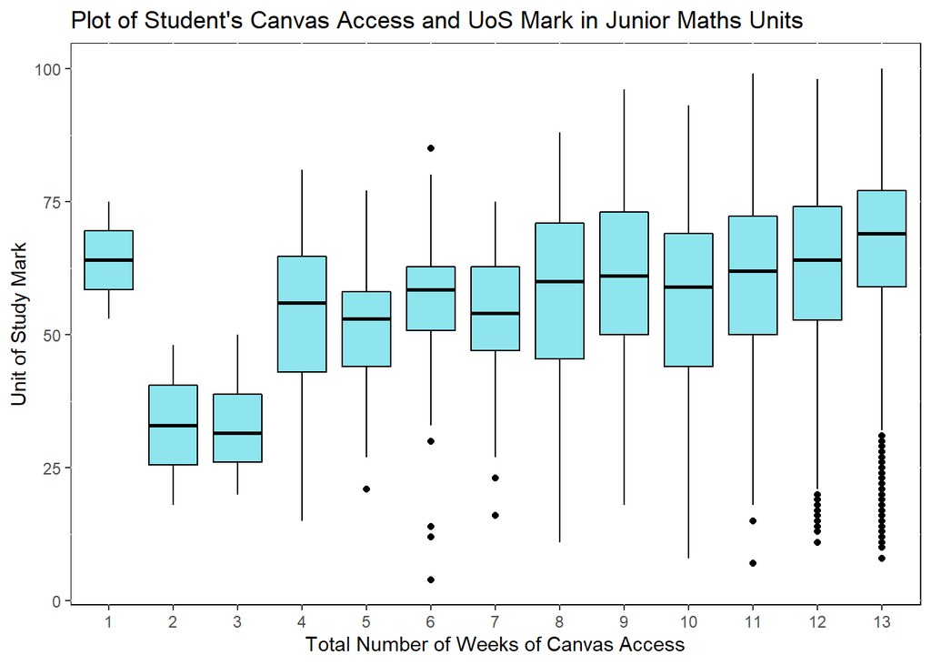

```r
#changing from number to factor
UniData$TotalCanvasAccess <- as.factor(UniData$TotalCanvasAccess)

#ggplot
ggplot(UniData, aes(x = TotalCanvasAccess, y = UoS.Mark)) + geom_boxplot(fill = "cadetblue2", color = "black") + theme(panel.background = element_rect(fill = "white", color = "black")) + xlab("Total Number of Weeks of Canvas Access") + ylab("Unit of Study Mark") + ggtitle("Plot of Student's Canvas Access and UoS Mark in Junior Maths Units")
```

# Conclusion

Through this data, a conclusive decision about whether the use of the university’s canvas website improved student marks cannot be made as data on the nature of student’s canvas usage is lacking. However with more data on the ways students use the canvas website include data on hours spent and number of times accessed on a whole throughout the week, a better understanding could be developed. This would help teaching staff such as unit coordinators to better plan and encourage students to use the materials avaliable on the Canvas page.